# Final Project Research Summary - Intro to Data Science - 6101

# 8 Classification Tree Modeling:

A classification tree defines as a structural mapping of binary decisions that lead to a decision about the class of an object. This is more properly a type of decision tree that leads to categorical decisions. Hence, we try to generate a Classification Tree Model using the balanced dataset for feature selected variables!

We fit the dataset using the model and the generate predicted values for the test set and compare it to the original y_test values.

[output not shown]

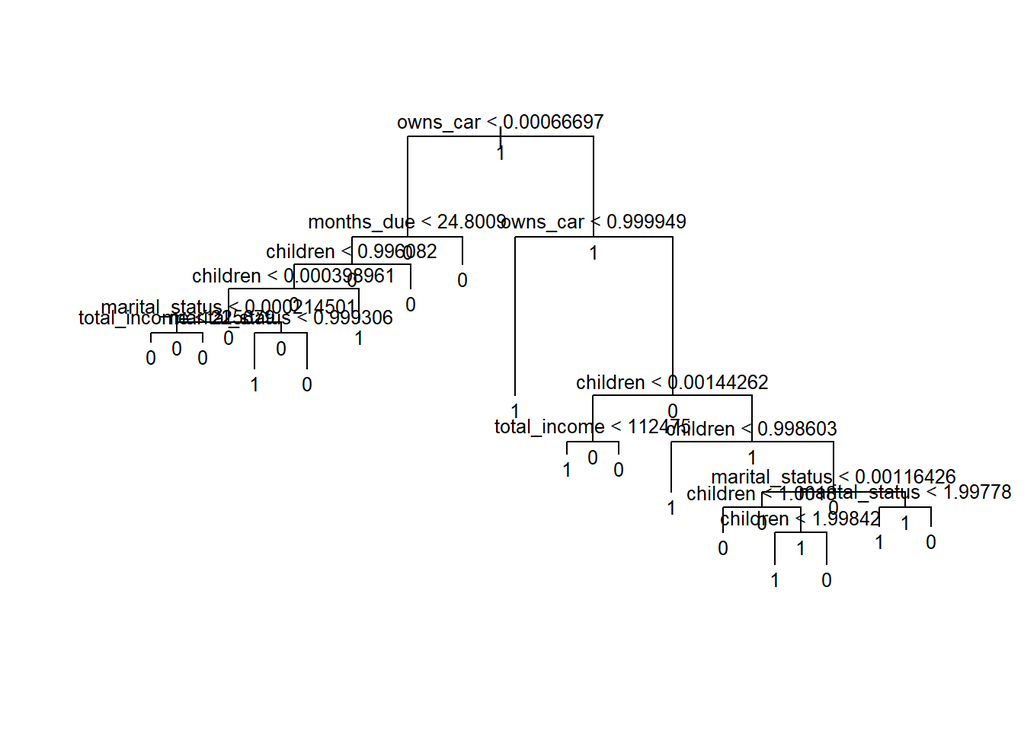

```r
# Fitting a Classification Tree
library(tree)
tree.credit <- tree(status~(owns_car+children+marital_status+months_due+owns_mobile+total_income), df2_bal)
summary(tree.credit)
# Residual mean deviance:  0.405 = 3230 / 7970
# Misclassification error rate: 0.0764 = 610 / 7986
plot(tree.credit)
text(tree.credit, all=TRUE, cex=.8)
```

```r
#using train and test sets in chunks above
tree.train <- tree(status~(owns_car+children+marital_status+months_due+owns_mobile+total_income), train)
status.test <- test$status
tree.pred <- predict(tree.train, test,type = "class")
table(tree.pred , status.test)
# find classification rate
# (769+695)/1597= 0.917
```

## 8.1 Using cross validation to Prune Tree

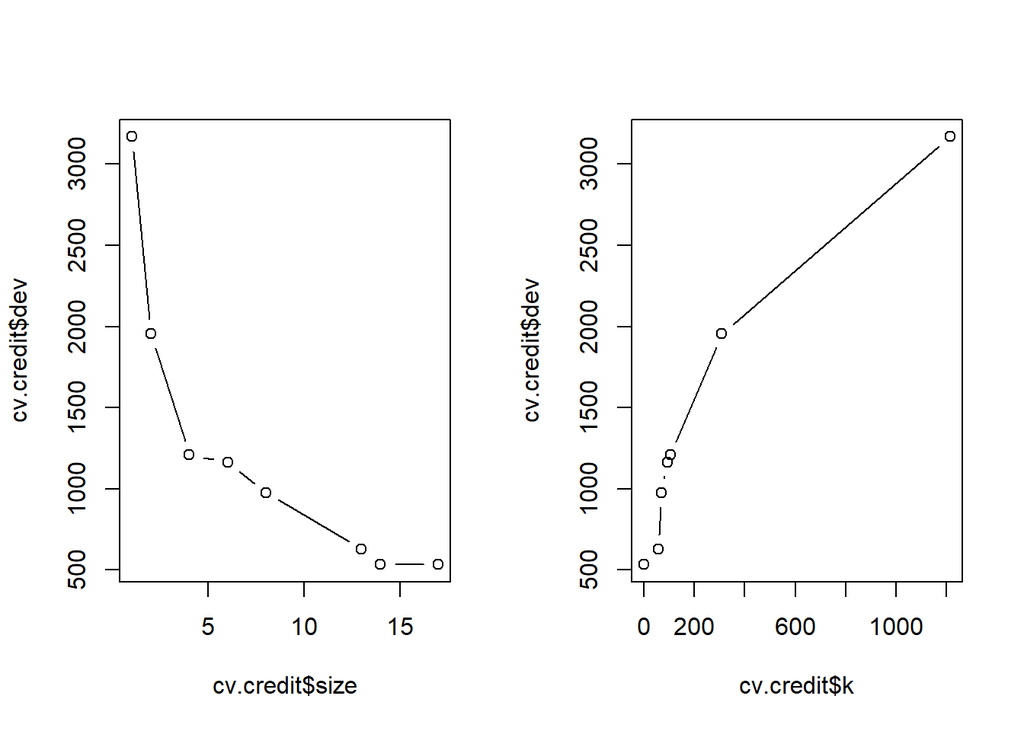

```r
set.seed (11)
cv.credit <- cv.tree(tree.train,
                       FUN =prune.misclass)
names(cv.credit)
#find size with the min dev
cv.credit$size
cv.credit$dev

par(mfrow = c(1, 2))
plot(cv.credit$size , cv.credit$dev, type = "b")
plot(cv.credit$k, cv.credit$dev, type = "b")
```

```r
#prune with size=16
#prune.credit <- prune.misclass(tree.credit , best = 16)
#plot(prune.credit)
#text(prune.credit, pretty = 0)
#tree.pred2 <- predict(prune.credit , test , type = "class")
#table(tree.pred2 ,status.test)
```

In this case, we will not prune the tree because it is already the best choice.

The model performs better than the above two Logistic Regression models and generates approximately a `91% accuracy`!

# 9 Conclusion:

After we used different statistical methods for the data set, below are our findings based on the different models generated:

- Balancing the data set is required to create a well performing model. Without a balanced data set, the model can undergo misclassification.
- Chi-Squared test was performed to find any relation between the dependent variable(y) and the regressors. The null model was rejected in all cases.
- The two AUC of Logit models were 0.71 and 0.62. the both results are below our goal of 0.80 or above.
- Classification Tree Model is the best suited for this category of dataset as this model result showed 91% accuracy rate.
- From observing the results of Logit Models and Feature Selection, we might say that these factors like previous months balance and marital status of a customer, whether they owning a car and a mobile phone, and having number of children generally increase the likelihood of that customer being issued a credit card by a bank.